# Auto gating update

April 11th, 2017

### OpenCyto

[Finak, Frelinger, Jiang, et al. (2014)](https://doi.org/10.1371%2Fjournal.pcbi.1003806)

- Mimics manual gating by focusing on 2 channels at a time
  - can follow traditional gate hierarchy
  - e.g. gate lymph, then single, then live, etc
- Pipeline templates defined in .csv file
  - defines algorithmic approach for each gate to be applied across many samples
  - not “just push go”, takes some setup for a decent template
- Results are interpretable and labelled populations
  - not geared toward detecting novel cell types

### OpenCyto

> The two top performing gating algorithms - OpenCyto (v. 1.7.4), flowDensity (v. 1.4.0) - in a study run by the FlowCAP consortium aimed at selecting the best performing algorithms for this larger study were chosen for the analysis presented in this paper. *Standardizing Flow Cytometry Immunophenotyping Analysis from the Human ImmunoPhenotyping Consortium* [Finak, Langweiler, Jaimes, et al. (2016)](https://doi.org/10.1038%2Fsrep20686)
- Stole template from above as a start
  - our panel 1 template currently lives [here](https://github.com/PankratzLab/auto-fcs/blob/master/explore/openCyto/lymph.dev.b.csv)

### Current progres overview

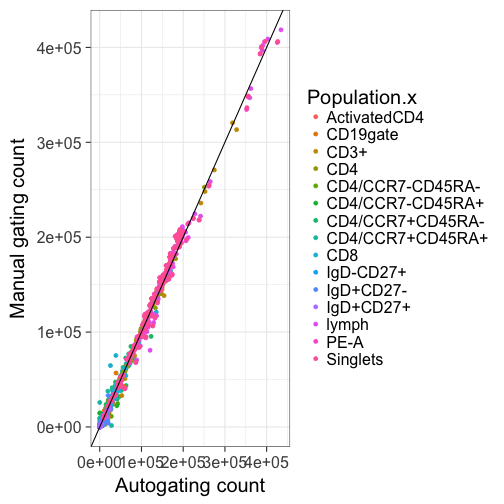

| N_SAMPS | N_DATA | RHO | BETA | BETA_SE | R2 | ICC_1 |
| --- | --- | --- | --- | --- | --- | --- |
| 151 | 2265 | 0.9867 | 1.015 | 0.0014 | 0.9956 | 0.9977 |

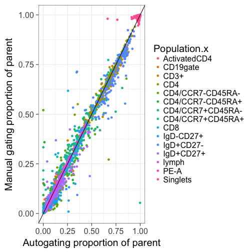

| N_SAMPS | N_DATA | RHO | BETA | BETA_SE | R2 | ICC_1 |
| --- | --- | --- | --- | --- | --- | --- |
| 151 | 2265 | 0.9811 | 0.9879 | 0.0029 | 0.9809 | 0.9903 |

### Lymphocytes (SSC-A v FSC-A)

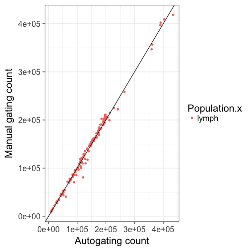

| N_SAMPS | N_DATA | RHO | BETA | BETA_SE | R2 | ICC_1 |
| --- | --- | --- | --- | --- | --- | --- |
| 151 | 151 | 0.9883 | 1.014 | 0.0078 | 0.9913 | 0.9954 |

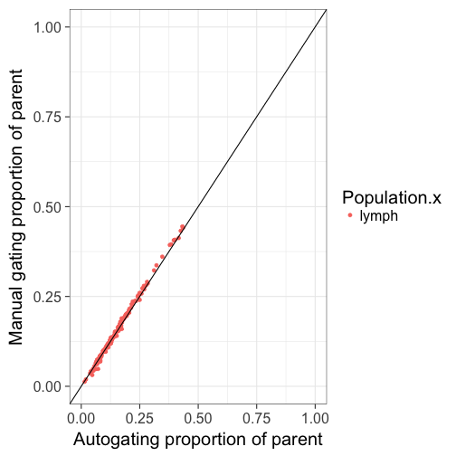

| N_SAMPS | N_DATA | RHO | BETA | BETA_SE | R2 | ICC_1 |
| --- | --- | --- | --- | --- | --- | --- |
| 151 | 151 | 0.9969 | 1.038 | 0.005 | 0.9966 | 0.9972 |

### Single Cells (FSC-H v FSC-W)

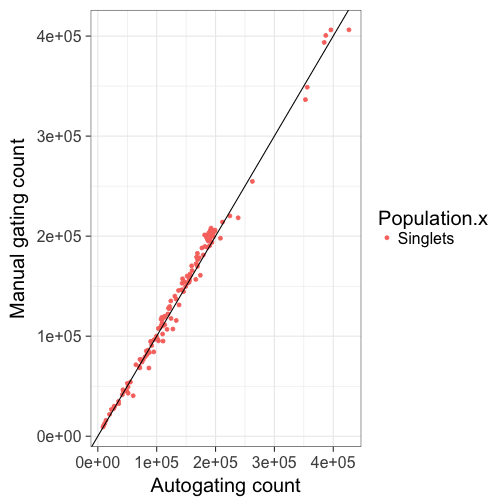

| N_SAMPS | N_DATA | RHO | BETA | BETA_SE | R2 | ICC_1 |
| --- | --- | --- | --- | --- | --- | --- |
| 151 | 151 | 0.9824 | 1.018 | 0.0087 | 0.9893 | 0.9935 |

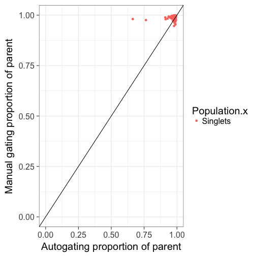

| N_SAMPS | N_DATA | RHO | BETA | BETA_SE | R2 | ICC_1 |
| --- | --- | --- | --- | --- | --- | --- |
| 151 | 151 | 0.0546 | 0.0321 | 0.0225 | 0.0134 | -0.0297 |

### Live cells (PE-)

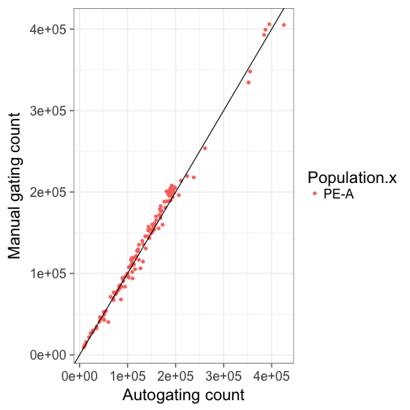

| N_SAMPS | N_DATA | RHO | BETA | BETA_SE | R2 | ICC_1 |
| --- | --- | --- | --- | --- | --- | --- |
| 151 | 151 | 0.9822 | 1.019 | 0.0088 | 0.989 | 0.9933 |

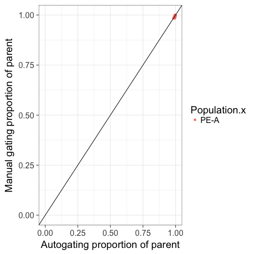

| N_SAMPS | N_DATA | RHO | BETA | BETA_SE | R2 | ICC_1 |
| --- | --- | --- | --- | --- | --- | --- |
| 151 | 151 | 0.679 | 1.073 | 0.0936 | 0.4687 | 0.6221 |

### Tcells (CD3+ CD19-)

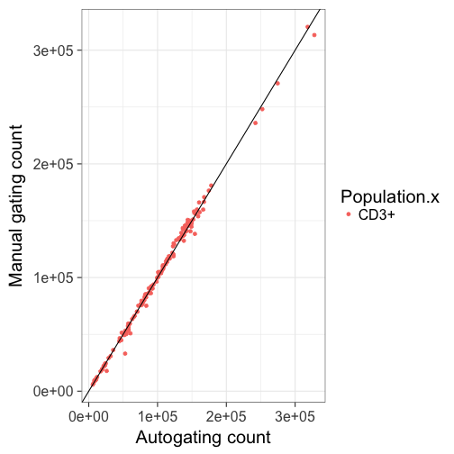

| N_SAMPS | N_DATA | RHO | BETA | BETA_SE | R2 | ICC_1 |
| --- | --- | --- | --- | --- | --- | --- |
| 151 | 151 | 0.9958 | 0.998 | 0.0054 | 0.9957 | 0.9978 |

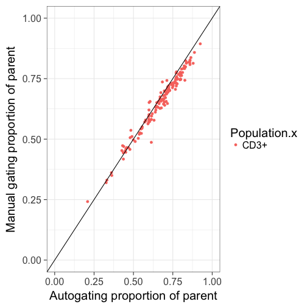

| N_SAMPS | N_DATA | RHO | BETA | BETA_SE | R2 | ICC_1 |
| --- | --- | --- | --- | --- | --- | --- |
| 151 | 151 | 0.9781 | 0.9063 | 0.0135 | 0.9682 | 0.9709 |

### Helper Tcells-CD4+

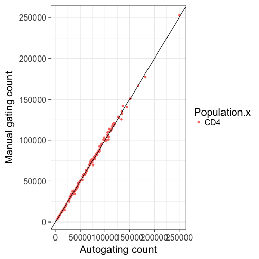

| N_SAMPS | N_DATA | RHO | BETA | BETA_SE | R2 | ICC_1 |
| --- | --- | --- | --- | --- | --- | --- |
| 151 | 151 | 0.9987 | 1.004 | 0.004 | 0.9977 | 0.9988 |

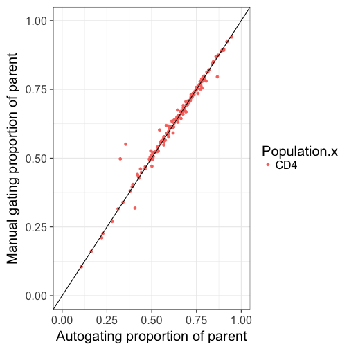

| N_SAMPS | N_DATA | RHO | BETA | BETA_SE | R2 | ICC_1 |
| --- | --- | --- | --- | --- | --- | --- |
| 151 | 151 | 0.9933 | 0.9647 | 0.0128 | 0.9744 | 0.9868 |

### central memory helper Tcells (CCR7+ CD45RA-)

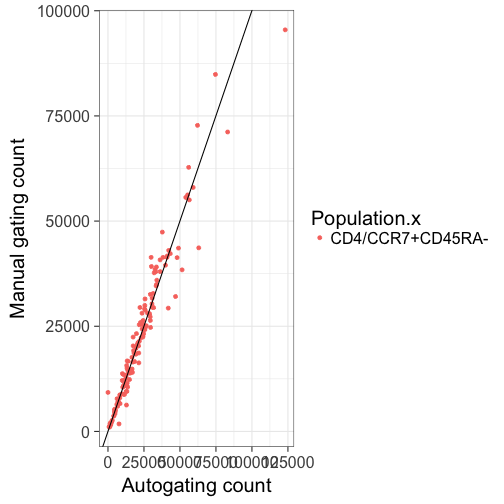

| N_SAMPS | N_DATA | RHO | BETA | BETA_SE | R2 | ICC_1 |
| --- | --- | --- | --- | --- | --- | --- |
| 151 | 151 | 0.98 | 0.9237 | 0.0204 | 0.9323 | 0.9649 |

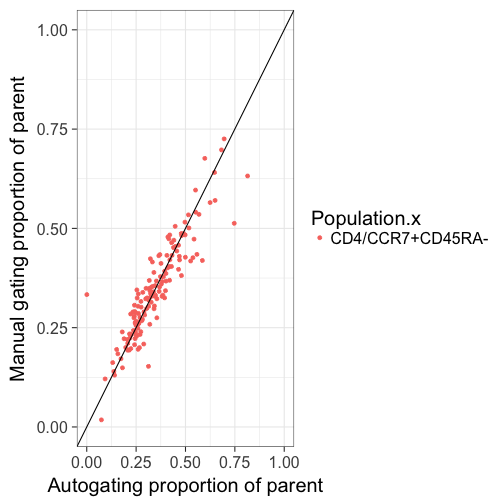

| N_SAMPS | N_DATA | RHO | BETA | BETA_SE | R2 | ICC_1 |
| --- | --- | --- | --- | --- | --- | --- |
| 151 | 151 | 0.9154 | 0.8088 | 0.0318 | 0.8131 | 0.8969 |

### effector helper Tcells (CCR7- CD45RA+)

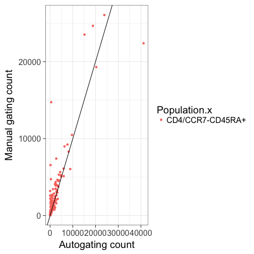

| N_SAMPS | N_DATA | RHO | BETA | BETA_SE | R2 | ICC_1 |
| --- | --- | --- | --- | --- | --- | --- |
| 151 | 151 | 0.7922 | 0.8244 | 0.0381 | 0.7587 | 0.8653 |

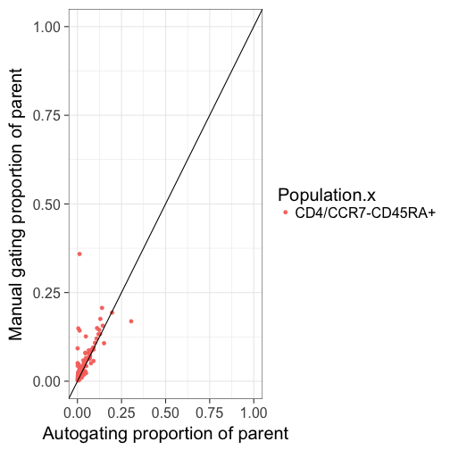

| N_SAMPS | N_DATA | RHO | BETA | BETA_SE | R2 | ICC_1 |
| --- | --- | --- | --- | --- | --- | --- |
| 151 | 151 | 0.7467 | 0.8182 | 0.0695 | 0.4816 | 0.6677 |

### effector memory helper Tcells (CCR7- CD45RA-)

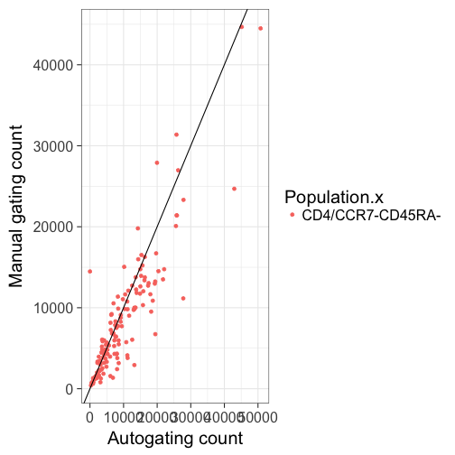

| N_SAMPS | N_DATA | RHO | BETA | BETA_SE | R2 | ICC_1 |
| --- | --- | --- | --- | --- | --- | --- |
| 151 | 151 | 0.8791 | 0.7816 | 0.0312 | 0.8082 | 0.8757 |

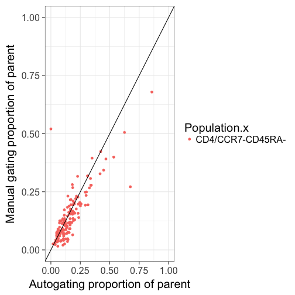

| N_SAMPS | N_DATA | RHO | BETA | BETA_SE | R2 | ICC_1 |
| --- | --- | --- | --- | --- | --- | --- |
| 151 | 151 | 0.8012 | 0.7023 | 0.0402 | 0.6721 | 0.7977 |

### naive helper Tcells (CCR7+ CD45RA+)

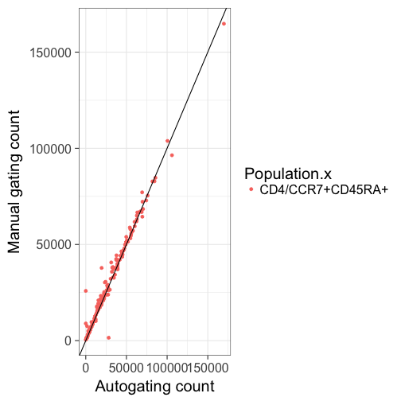

| N_SAMPS | N_DATA | RHO | BETA | BETA_SE | R2 | ICC_1 |
| --- | --- | --- | --- | --- | --- | --- |
| 151 | 151 | 0.9711 | 0.9695 | 0.0129 | 0.9743 | 0.9861 |

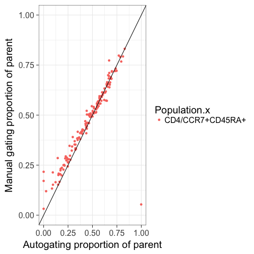

| N_SAMPS | N_DATA | RHO | BETA | BETA_SE | R2 | ICC_1 |
| --- | --- | --- | --- | --- | --- | --- |
| 151 | 151 | 0.9516 | 0.7982 | 0.0315 | 0.8119 | 0.8931 |

### cytotoxic Tcells-CD8+

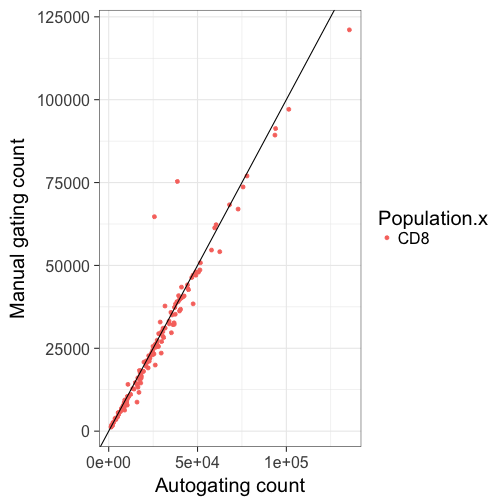

| N_SAMPS | N_DATA | RHO | BETA | BETA_SE | R2 | ICC_1 |
| --- | --- | --- | --- | --- | --- | --- |
| 151 | 151 | 0.9866 | 0.9615 | 0.0192 | 0.944 | 0.9712 |

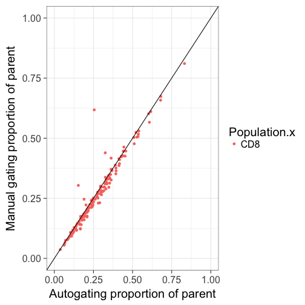

| N_SAMPS | N_DATA | RHO | BETA | BETA_SE | R2 | ICC_1 |
| --- | --- | --- | --- | --- | --- | --- |
| 151 | 151 | 0.9688 | 0.9794 | 0.0226 | 0.9268 | 0.9612 |

### B cells (CD3- CD19+)

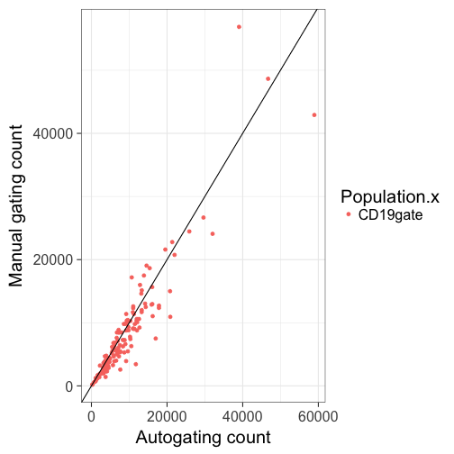

| N_SAMPS | N_DATA | RHO | BETA | BETA_SE | R2 | ICC_1 |
| --- | --- | --- | --- | --- | --- | --- |
| 151 | 151 | 0.9379 | 0.9252 | 0.0296 | 0.8676 | 0.9261 |

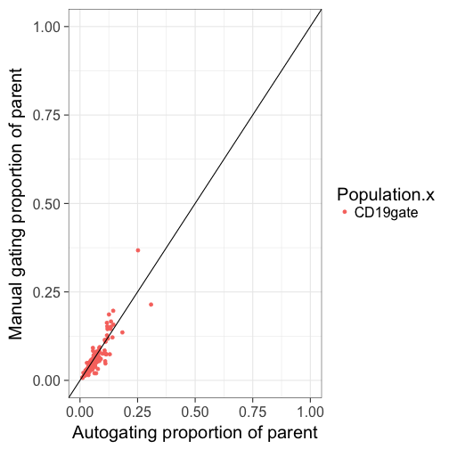

| N_SAMPS | N_DATA | RHO | BETA | BETA_SE | R2 | ICC_1 |
| --- | --- | --- | --- | --- | --- | --- |
| 151 | 151 | 0.8811 | 1.002 | 0.0429 | 0.7858 | 0.8715 |

### Summary

- OpenCyto seems to work
- Lots of room for improvement
- Iterative process

### ICC

From [Wikipedia](https://en.wikipedia.org/wiki/Intraclass_correlation)

[Cicchetti (1994)](https://doi.org/10.1037%2F1040-3590.6.4.284) gives the following often quoted guidelines for interpretation for kappa or ICC inter-rater agreement measures:

- Less than 0.40—poor.
- Between 0.40 and 0.59—Fair.
- Between 0.60 and 0.74—Good.
- Between 0.75 and 1.00—Excellent.